# Shixiang Wang 王诗翔

wangsx1@sysucc.org.cn  
github.com/ShixiangWang  
[ORCID](https://orcid.org/0000-0001-9855-7357) [Scholar](https://scholar.google.com/citations?hl=en&user=FvNp0NkAAAAJ)

## Research summary

I am a computational biologist working on cancer genomics. I use bioinformatics skills to decode the unfound patterns in cancer, and explore biomarkers for explaining the cancer heterogeneity and predicting the efficacy of cancer treatments, mainly in immunotherapy.

**I am passionate about** open science and developing open-source analysis toolkits. Because of this, currently I am a community member of Openbiox[^1], rOpenSci[^2] and Bioconductor[^3]. My long-term goal in academic field is being a master in a subfield of cancer bioinformatics and trying my best to continually boost the open-source bioinformatics ecosystem in China.

## Research positions

| year | what |
| --- | --- |
| 2021 — present | Postdoctoral Researcher, Experiment Research Department, Sun Yat-sen University Cancer Center[^4] Supervisor: Prof. Rui-Hua Xu[^5]; Cooperate with Prof. Qi Zhao[^6] |

## Education

| year | what |
| --- | --- |
| 2016 — 2021 | PhD in Cancer Biology, ShanghaiTech University[^7] & Shanghai Institute of Biochemistry and Cell Biology, Chinese Academy of Sciences[^8] Supervisor: Prof. Xue-Song Liu[^9] |
| 2012 — 2016 | B.E. in Biomedical Engineering, University of Electronic Science and Technology of China Supervisor: Prof. Yang Xia |

## Major grants and funding

| year | what |
| --- | --- |
| 2022 — 2023 | China Postdoctoral Science Foundation[^10] (¥ 80k), General Project |
| 2024 — 2026 | National Natural Science Foundation of China[^11] (¥ 300k), Young Scientists Fund |

## Awards & honours

| year | what |
| --- | --- |
| 2021 | 2021 Outstanding Graduate Award, ShanghaiTech University |
| 2020 | National Scholarship for Doctoral Students, ShanghaiTech University |
|  | ShanghaiTech University Class A Postgraduate Academic Scholarship, ShanghaiTech University |

## Publications

### Journal articles (fully reviewed, † for co-first, * for corresponding)

[output not shown]

> The journal impact factors mentioned above are derived from the maximum values in the history of journal impact factors. Journal impact factors, Chinese Academy of Sciences (CAS) categorization, and JCR categorization were all uniformly updated on 2023.11.02. For future publications that are included, I will update them selectively and will no longer perform uniform updates on all publications.

### Preprints (not reviewed, † for co-first, * for corresponding)

[output not shown]

## Cited by

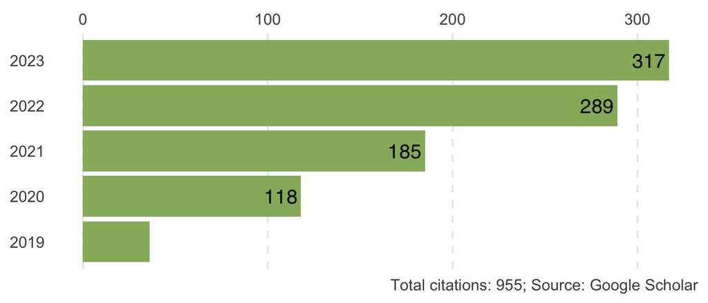

## Talks

| year | number | what |
| --- | --- | --- |
| 2020 | T1 | BioC Asia 2020[^12], Online Sigflow: an automated and comprehensive pipeline for cancer genome mutational signature analysis[^13] |
| 2023 | T2 | 中南大学, 湘雅 中德学术研讨会, Online Machine learning-based extrachromosomal DNA identification in large-scale cohorts reveals its clinical implications in cancer |

## Poster presentations

| year | number | what |
| --- | --- | --- |
| 2019 | P1 | ShanghaiTech University, BioForum 2019, Shanghai, China Antigen presentation and tumor immunogenicity in cancer immunotherapy response prediction |
| 2020 | P2 | BioC Asia 2020[^14] Sigflow: an automated and comprehensive pipeline for cancer genome mutational signature analysis[^15] |

## Teaching experience

| year | what |
| --- | --- |
| 2019 | Teaching assistant, Cancer Biology, ShanghaiTech University Teacher: Xue-Song Liu |
| 2023 | Supervisor, Open Source Promotion Plan 2023[^16] Student: Shensuo Li |

## Service

[output not shown]

# Links

[^1]: https://github.com/openbiox
[^2]: https://ropensci.org/
[^3]: https://www.bioconductor.org/
[^4]: http://english.sysucc.org.cn/
[^5]: http://english.sysucc.org.cn/info_19.aspx?itemid=154
[^6]: https://seqworld.com/
[^7]: https://www.shanghaitech.edu.cn/
[^8]: http://cemcs.cas.cn/
[^9]: https://slst.shanghaitech.edu.cn/lxs_en/main.htm
[^10]: https://jj.chinapostdoctor.org.cn/website/index.html
[^11]: https://www.nsfc.gov.cn/
[^12]: https://biocasia2020.bioconductor.org/
[^13]: https://www.youtube.com/watch?v=nzAxPDTznm4
[^14]: https://biocasia2020.bioconductor.org/
[^15]: https://f1000research.com/posters/9-1217
[^16]: https://summer-ospp.ac.cn/org/prodetail/2351d0245?lang=zh&list=pro
[^17]: https://www.frontiersin.org/
[^18]: https://openbiox.github.io/weekly/
[^19]: https://academic.oup.com/bib
[^20]: https://translational-medicine.biomedcentral.com/
[^21]: https://www.cell.com/star-protocols/home
[^22]: https://www.frontiersin.org/journals/immunology
[^23]: https://www.frontiersin.org/journals/oncology
[^24]: https://www.frontiersin.org/journals/cell-and-developmental-biology